# Data Presentation and Formulation of the Problem

## 🔍 The Problem:

- The company needs to reduce its costs in the face of the drop in the value of pulp in the international market.
- One of the fronts in this endeavor is to reduce the maintenance costs of its resources, making it more precise and objective, working within what is necessary, without this harming production, of course.

## 🎲 The Data:

- For this purpose, the maintenance team provided us with a historical series of each resource that failed at some point, totaling 100 assets, and another table with another 100 assets to test the model's fidelity.

🤓 So we have this table:

- The identification of each asset
- A runtime counter
- The settings used
- And the measurement of 21 sensors in each of these assets

|  | Asset id | runtime | setting_1 | setting_2 | setting_3 | Tag1 | Tag2 | Tag3 | Tag4 | Tag5 | ... | Tag12 | Tag13 | Tag14 | Tag15 | Tag16 | Tag17 | Tag18 | Tag19 | Tag20 | Tag21 |
| --- | --- | --- | --- | --- | --- | --- | --- | --- | --- | --- | --- | --- | --- | --- | --- | --- | --- | --- | --- | --- | --- |
| 0 | 1 | 1 | -0.0007 | -0.0004 | 100.0 | 518.67 | 641.82 | 1589.70 | 1400.60 | 14.62 | ... | 521.66 | 2388.02 | 8138.62 | 8.4195 | 0.03 | 392 | 2388 | 100.0 | 39.06 | 23.4190 |
| 1 | 1 | 2 | 0.0019 | -0.0003 | 100.0 | 518.67 | 642.15 | 1591.82 | 1403.14 | 14.62 | ... | 522.28 | 2388.07 | 8131.49 | 8.4318 | 0.03 | 392 | 2388 | 100.0 | 39.00 | 23.4236 |
| 2 | 1 | 3 | -0.0043 | 0.0003 | 100.0 | 518.67 | 642.35 | 1587.99 | 1404.20 | 14.62 | ... | 522.42 | 2388.03 | 8133.23 | 8.4178 | 0.03 | 390 | 2388 | 100.0 | 38.95 | 23.3442 |
| 3 | 1 | 4 | 0.0007 | 0.0000 | 100.0 | 518.67 | 642.35 | 1582.79 | 1401.87 | 14.62 | ... | 522.86 | 2388.08 | 8133.83 | 8.3682 | 0.03 | 392 | 2388 | 100.0 | 38.88 | 23.3739 |
| 4 | 1 | 5 | -0.0019 | -0.0002 | 100.0 | 518.67 | 642.37 | 1582.85 | 1406.22 | 14.62 | ... | 522.19 | 2388.04 | 8133.80 | 8.4294 | 0.03 | 393 | 2388 | 100.0 | 38.90 | 23.4044 |

5 rows × 26 columns

## 🎯 The main goal is to evaluate the feasibility of a model capable of predicting the maintenance of each asset 20 cycles in advance.

# Exploratory Data Analysis

## 🆔 ⏳ Assets and Runtimes

We have 20631 observations, each one related to an asset execution.

Let's visualize the number of operations performed for each asset and observe some general statistics about it.

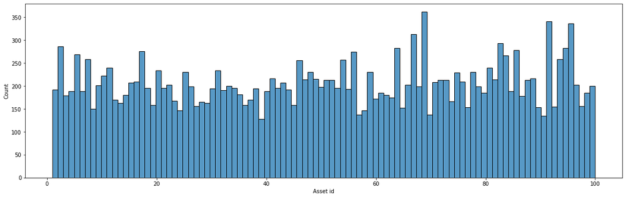

|  | runtime |
| --- | --- |
| count | 100.000000 |
| mean | 206.310000 |
| std | 46.342749 |
| min | 128.000000 |
| 25% | 177.000000 |
| 50% | 199.000000 |
| 75% | 229.250000 |
| max | 362.000000 |

The statistics suggest that, on average, assets last between 199 and 209 runtimes. We can also see that the asset that failed the earliest was consumed only 128 times, and the longest was used 362 times.

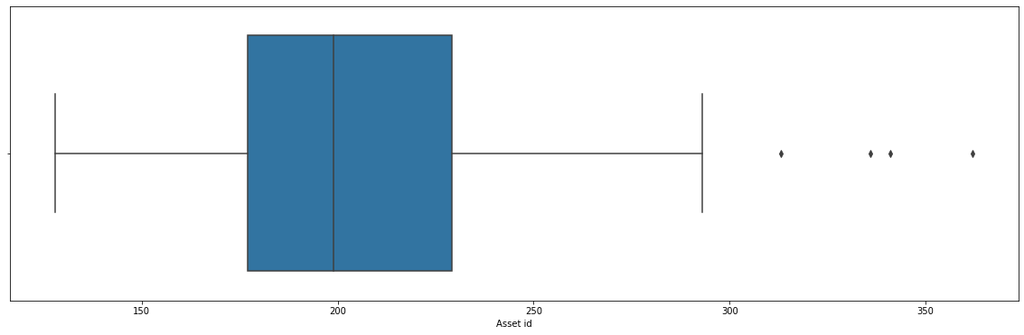

## ⚙️ Settings

The second layer of the dataset is the Settings used to run each asset, let's see:

|  | setting_1 | setting_2 | setting_3 |
| --- | --- | --- | --- |
| count | 20631.000000 | 20631.000000 | 20631.0 |
| mean | -0.000009 | 0.000002 | 100.0 |
| std | 0.002187 | 0.000293 | 0.0 |
| min | -0.008700 | -0.000600 | 100.0 |
| 25% | -0.001500 | -0.000200 | 100.0 |
| 50% | 0.000000 | 0.000000 | 100.0 |
| 75% | 0.001500 | 0.000300 | 100.0 |
| max | 0.008700 | 0.000600 | 100.0 |

As we can see from the standard deviation, there are no considerable changes in the settings pattern. This suggests (and only suggests as we don't have more details on what exactly these settings are) that the assets are used within a stable production line with little variation.

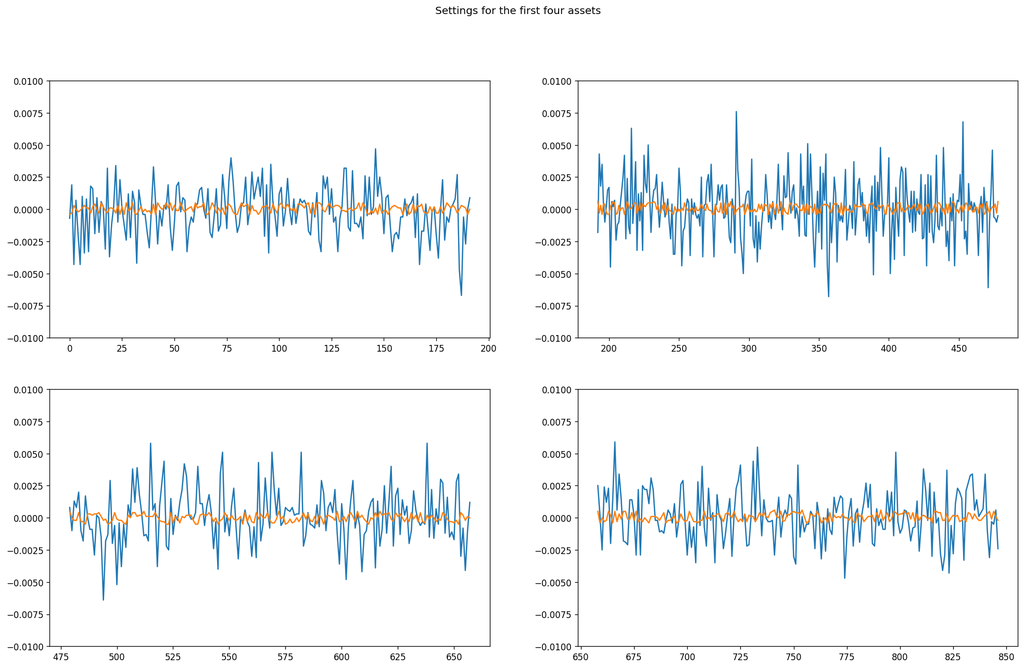

## 🏷️ Tags

Last but not least we have all the 21 tags representing the reading of each monitoring sensor of the asset, let's take a look:

|  | count | mean | std | min | 25% | 50% | 75% | max |
| --- | --- | --- | --- | --- | --- | --- | --- | --- |
| Tag1 | 20631.0 | 518.670000 | 0.000000e+00 | 518.6700 | 518.6700 | 518.6700 | 518.6700 | 518.6700 |
| Tag2 | 20631.0 | 642.680934 | 5.000533e-01 | 641.2100 | 642.3250 | 642.6400 | 643.0000 | 644.5300 |
| Tag3 | 20631.0 | 1590.523119 | 6.131150e+00 | 1571.0400 | 1586.2600 | 1590.1000 | 1594.3800 | 1616.9100 |
| Tag4 | 20631.0 | 1408.933782 | 9.000605e+00 | 1382.2500 | 1402.3600 | 1408.0400 | 1414.5550 | 1441.4900 |
| Tag5 | 20631.0 | 14.620000 | 1.776400e-15 | 14.6200 | 14.6200 | 14.6200 | 14.6200 | 14.6200 |
| Tag6 | 20631.0 | 21.609803 | 1.388985e-03 | 21.6000 | 21.6100 | 21.6100 | 21.6100 | 21.6100 |
| Tag7 | 20631.0 | 553.367711 | 8.850923e-01 | 549.8500 | 552.8100 | 553.4400 | 554.0100 | 556.0600 |
| Tag8 | 20631.0 | 2388.096652 | 7.098548e-02 | 2387.9000 | 2388.0500 | 2388.0900 | 2388.1400 | 2388.5600 |
| Tag9 | 20631.0 | 9065.242941 | 2.208288e+01 | 9021.7300 | 9053.1000 | 9060.6600 | 9069.4200 | 9244.5900 |
| Tag10 | 20631.0 | 1.300000 | 0.000000e+00 | 1.3000 | 1.3000 | 1.3000 | 1.3000 | 1.3000 |
| Tag11 | 20631.0 | 47.541168 | 2.670874e-01 | 46.8500 | 47.3500 | 47.5100 | 47.7000 | 48.5300 |
| Tag12 | 20631.0 | 521.413470 | 7.375534e-01 | 518.6900 | 520.9600 | 521.4800 | 521.9500 | 523.3800 |
| Tag13 | 20631.0 | 2388.096152 | 7.191892e-02 | 2387.8800 | 2388.0400 | 2388.0900 | 2388.1400 | 2388.5600 |
| Tag14 | 20631.0 | 8143.752722 | 1.907618e+01 | 8099.9400 | 8133.2450 | 8140.5400 | 8148.3100 | 8293.7200 |
| Tag15 | 20631.0 | 8.442146 | 3.750504e-02 | 8.3249 | 8.4149 | 8.4389 | 8.4656 | 8.5848 |
| Tag16 | 20631.0 | 0.030000 | 1.387812e-17 | 0.0300 | 0.0300 | 0.0300 | 0.0300 | 0.0300 |
| Tag17 | 20631.0 | 393.210654 | 1.548763e+00 | 388.0000 | 392.0000 | 393.0000 | 394.0000 | 400.0000 |
| Tag18 | 20631.0 | 2388.000000 | 0.000000e+00 | 2388.0000 | 2388.0000 | 2388.0000 | 2388.0000 | 2388.0000 |
| Tag19 | 20631.0 | 100.000000 | 0.000000e+00 | 100.0000 | 100.0000 | 100.0000 | 100.0000 | 100.0000 |
| Tag20 | 20631.0 | 38.816271 | 1.807464e-01 | 38.1400 | 38.7000 | 38.8300 | 38.9500 | 39.4300 |
| Tag21 | 20631.0 | 23.289705 | 1.082509e-01 | 22.8942 | 23.2218 | 23.2979 | 23.3668 | 23.6184 |

It's a little messy to analyze all those numbers, let's make some viz

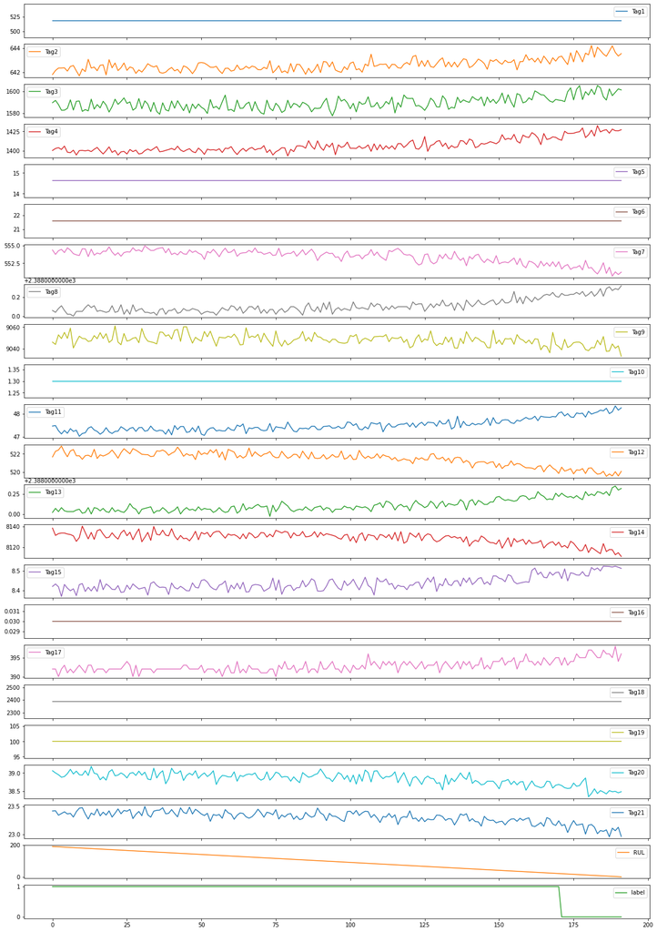

👀 So, what can we intuit from the combination of the statistical summary and the visualization of the sensors for each asset?

1. There is no variation for some sensors (`Tag1`, `Tag10`, `Tag18` and `Tag19`) along the data, as we can see by the recurrence of one same value with no standard deviation associated, so maybe we can drop them out to preserve only useful information and prevent further model overfitting.
2. In this visualization for the first asset sensors, we can see a tendency in the variation indicating a future failure, usually in the final quarter of the data. This is a good indication that there is a pattern that the model can rely on to make the prediction.

## 💀 Remaining Useful Life (RUL)

To advance the analysis and the possibility of prediction, we can use the concept of remaining useful life - RUL. It will work as a coefficient to indicate how many cycles each asset has to failure, like a countdown. To calculate it is simple: as we already have information about the useful life of each of the assets, we just have to invert the count.

And we have the following distribution:

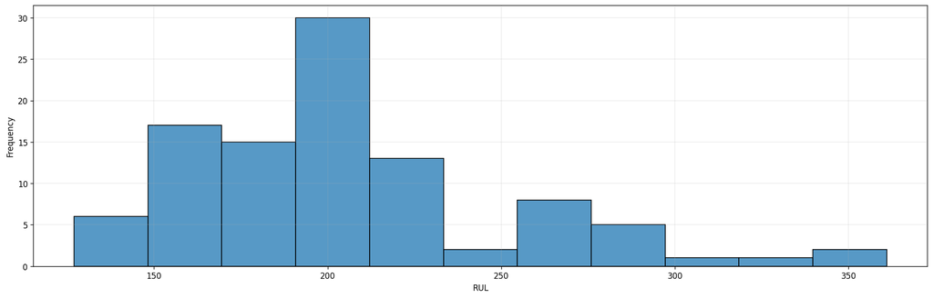

Or, we can also work with the RUL to better visualize the correlation between the sensor data and the failure.

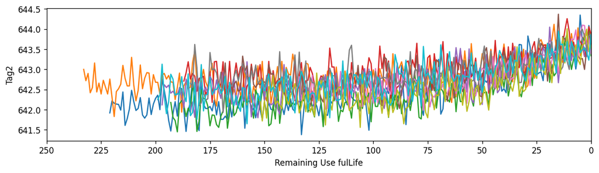

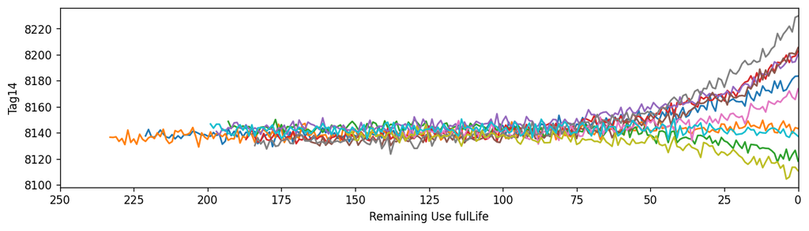

We can also observe which sensors do not add relevant information to the construction of a linear model.

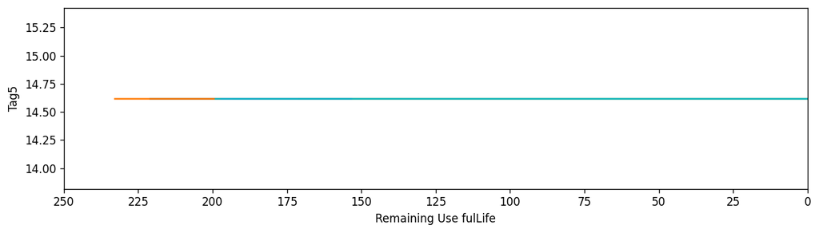

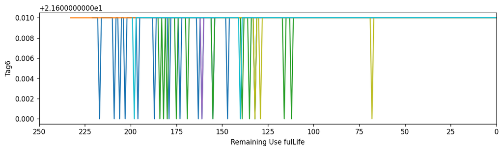

## Conclusions 🤔

✅ Settings have little or no impact on building a predictive model.

✅ We can use RUL calculation to correlate variables and predict future failure.

✅ Some sensors present irrelevant data for the construction of a linear model, which we will discard at first.

# Modeling

## Logistic regression baseline

Our first job is to create a model that is capable of recognizing an asset failure with 20 cycles. We can do this using simple logistic regression.

```
              precision    recall  f1-score   support

           0       1.00      1.00      1.00       375
           1       1.00      1.00      1.00      3752

    accuracy                           1.00      4127
   macro avg       1.00      1.00      1.00      4127
weighted avg       1.00      1.00      1.00      4127
```

The results are excellent! From the training dataset we can recognize a failure 20 cycles in advance with 100% certainty. Obviously, the ideal is to test with more data not worked by the model, but this already gives us great security to guide the maintenance routine.

## Data procesing

The next step is to create a model that can predict how many cycles each asset has available until the next failure.

For this, we will prepare the data to be coherent: eliminate sensors that do not add relevant information to the model, reduce the weight of outliers by scaling the data, create polynomial combinations for each feature, and focusing on the final trend that the sensor data presents before failure, rather than considering that the degradation is linear from start to finish (which cannot be observed with such precision).

## Regression baseline

Let's start with a simple linear regression with the training dataset and observe the initial performance that we can base on.

```
RMSE:18.763818622288873, R2:0.7729827657293247
```

The R² means how much of the model explains the variance of the dependent variable from the regressors, and we can use it as a basic metric for the efficiency of the model and compare later with others. The higher the value (up to 1) the more efficient is the model.

## XGBoost

Here I will use a model that I like to work with because it has high performance for the most varied types of problems, the XGBoost.

```
RMSE:18.33642899230519, R2:0.7832066791831965
```

We can observe an increase in R² (accompanied by a reduction in RMSE), indicating that the model has better performance. But the great advantage of working with XGBoost is using its hyperparameters, let's run a random search in search of the best values for these parameters:

[output not shown]

[output not shown]

[output cut: 136 more lines]

[output not shown]